# Loan_Data_from_Prosper slides

## Prosper Loan Data Exploratory Analysis

Import Packages:

```python
import pandas as pd
import numpy as np
import matplotlib.pyplot as plt
import seaborn as sb

%matplotlib inline
```

Read & Analyse Data assets:

```python
df = pd.read_csv("prosperLoanData.csv")
```

```python
df.info()
```

```
<class 'pandas.core.frame.DataFrame'>
RangeIndex: 113937 entries, 0 to 113936
Data columns (total 81 columns):
ListingKey                             113937 non-null object
ListingNumber                          113937 non-null int64
ListingCreationDate                    113937 non-null object
CreditGrade                            28953 non-null object
Term                                   113937 non-null int64
LoanStatus                             113937 non-null object
ClosedDate                             55089 non-null object
BorrowerAPR                            113912 non-null float64
BorrowerRate                           113937 non-null float64
LenderYield                            113937 non-null float64
EstimatedEffectiveYield                84853 non-null float64
EstimatedLoss                          84853 non-null float64
EstimatedReturn                        84853 non-null float64
ProsperRating (numeric)                84853 non-null float64
ProsperRating (Alpha)                  84853 non-null object
ProsperScore                           84853 non-null float64
ListingCategory (numeric)              113937 non-null int64
BorrowerState                          108422 non-null object
Occupation                             110349 non-null object
EmploymentStatus                       111682 non-null object
EmploymentStatusDuration               106312 non-null float64
IsBorrowerHomeowner                    113937 non-null bool
CurrentlyInGroup                       113937 non-null bool
GroupKey                               13341 non-null object
DateCreditPulled                       113937 non-null object
CreditScoreRangeLower                  113346 non-null float64
CreditScoreRangeUpper                  113346 non-null float64
FirstRecordedCreditLine                113240 non-null object
CurrentCreditLines                     106333 non-null float64
OpenCreditLines                        106333 non-null float64
TotalCreditLinespast7years             113240 non-null float64
OpenRevolvingAccounts                  113937 non-null int64
OpenRevolvingMonthlyPayment            113937 non-null float64
InquiriesLast6Months                   113240 non-null float64
TotalInquiries                         112778 non-null float64
CurrentDelinquencies                   113240 non-null float64
AmountDelinquent                       106315 non-null float64
```

[output cut: 31 more lines]

```
LP_CustomerPayments                    113937 non-null float64
LP_CustomerPrincipalPayments           113937 non-null float64
LP_InterestandFees                     113937 non-null float64
LP_ServiceFees                         113937 non-null float64
LP_CollectionFees                      113937 non-null float64
LP_GrossPrincipalLoss                  113937 non-null float64
LP_NetPrincipalLoss                    113937 non-null float64
LP_NonPrincipalRecoverypayments        113937 non-null float64
PercentFunded                          113937 non-null float64
Recommendations                        113937 non-null int64
InvestmentFromFriendsCount             113937 non-null int64
InvestmentFromFriendsAmount            113937 non-null float64
Investors                              113937 non-null int64
dtypes: bool(3), float64(50), int64(11), object(17)
memory usage: 68.1+ MB
```

```python
df.describe()
```

|  | ListingNumber | Term | BorrowerAPR | BorrowerRate | LenderYield | EstimatedEffectiveYield | EstimatedLoss | EstimatedReturn | ProsperRating (numeric) | ProsperScore | ... | LP_ServiceFees | LP_CollectionFees | LP_GrossPrincipalLoss | LP_NetPrincipalLoss | LP_NonPrincipalRecoverypayments | PercentFunded | Recommendations | InvestmentFromFriendsCount | InvestmentFromFriendsAmount | Investors |
| --- | --- | --- | --- | --- | --- | --- | --- | --- | --- | --- | --- | --- | --- | --- | --- | --- | --- | --- | --- | --- | --- |
| count | 1.139370e+05 | 113937.000000 | 113912.000000 | 113937.000000 | 113937.000000 | 84853.000000 | 84853.000000 | 84853.000000 | 84853.000000 | 84853.000000 | ... | 113937.000000 | 113937.000000 | 113937.000000 | 113937.000000 | 113937.000000 | 113937.000000 | 113937.000000 | 113937.000000 | 113937.000000 | 113937.000000 |
| mean | 6.278857e+05 | 40.830248 | 0.218828 | 0.192764 | 0.182701 | 0.168661 | 0.080306 | 0.096068 | 4.072243 | 5.950067 | ... | -54.725641 | -14.242698 | 700.446342 | 681.420499 | 25.142686 | 0.998584 | 0.048027 | 0.023460 | 16.550751 | 80.475228 |
| std | 3.280762e+05 | 10.436212 | 0.080364 | 0.074818 | 0.074516 | 0.068467 | 0.046764 | 0.030403 | 1.673227 | 2.376501 | ... | 60.675425 | 109.232758 | 2388.513831 | 2357.167068 | 275.657937 | 0.017919 | 0.332353 | 0.232412 | 294.545422 | 103.239020 |
| min | 4.000000e+00 | 12.000000 | 0.006530 | 0.000000 | -0.010000 | -0.182700 | 0.004900 | -0.182700 | 1.000000 | 1.000000 | ... | -664.870000 | -9274.750000 | -94.200000 | -954.550000 | 0.000000 | 0.700000 | 0.000000 | 0.000000 | 0.000000 | 1.000000 |
| 25% | 4.009190e+05 | 36.000000 | 0.156290 | 0.134000 | 0.124200 | 0.115670 | 0.042400 | 0.074080 | 3.000000 | 4.000000 | ... | -73.180000 | 0.000000 | 0.000000 | 0.000000 | 0.000000 | 1.000000 | 0.000000 | 0.000000 | 0.000000 | 2.000000 |
| 50% | 6.005540e+05 | 36.000000 | 0.209760 | 0.184000 | 0.173000 | 0.161500 | 0.072400 | 0.091700 | 4.000000 | 6.000000 | ... | -34.440000 | 0.000000 | 0.000000 | 0.000000 | 0.000000 | 1.000000 | 0.000000 | 0.000000 | 0.000000 | 44.000000 |
| 75% | 8.926340e+05 | 36.000000 | 0.283810 | 0.250000 | 0.240000 | 0.224300 | 0.112000 | 0.116600 | 5.000000 | 8.000000 | ... | -13.920000 | 0.000000 | 0.000000 | 0.000000 | 0.000000 | 1.000000 | 0.000000 | 0.000000 | 0.000000 | 115.000000 |
| max | 1.255725e+06 | 60.000000 | 0.512290 | 0.497500 | 0.492500 | 0.319900 | 0.366000 | 0.283700 | 7.000000 | 11.000000 | ... | 32.060000 | 0.000000 | 25000.000000 | 25000.000000 | 21117.900000 | 1.012500 | 39.000000 | 33.000000 | 25000.000000 | 1189.000000 |

8 rows × 61 columns

#### Univariate Analysis:

In this step, we will be study Individual Variables.

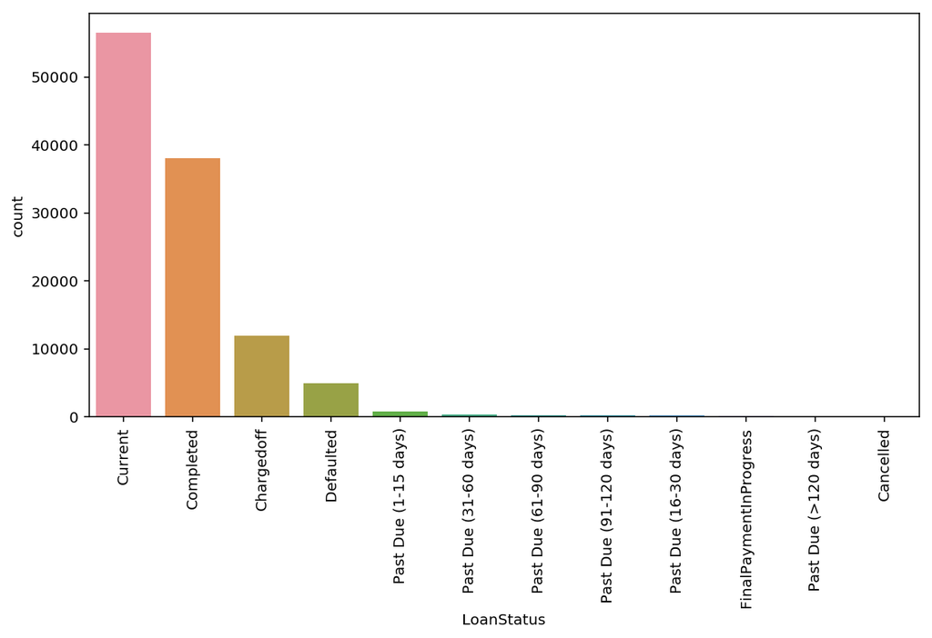

```python
plt.figure(figsize = [10, 5])
order=df['LoanStatus'].value_counts()
sb.countplot(data=df,x="LoanStatus",order=order.index)
plt.xticks(rotation=90);
```

Observations: Looking at the Loan Status within Prosper Data, its visible that the majority of the Loan status is Active followed by Completed.

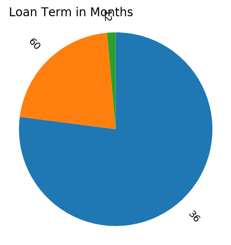

```python
order=df['Term'].value_counts()
plt.pie(order, labels = order.index, startangle = 90,counterclock = False,  rotatelabels =True);
plt.axis('square')

plt.title('Loan Term in Months',loc='left');
```

Observations: It is noted from Prosper Loan data that most Loans are Termed 36 Months, followed by 60 Months

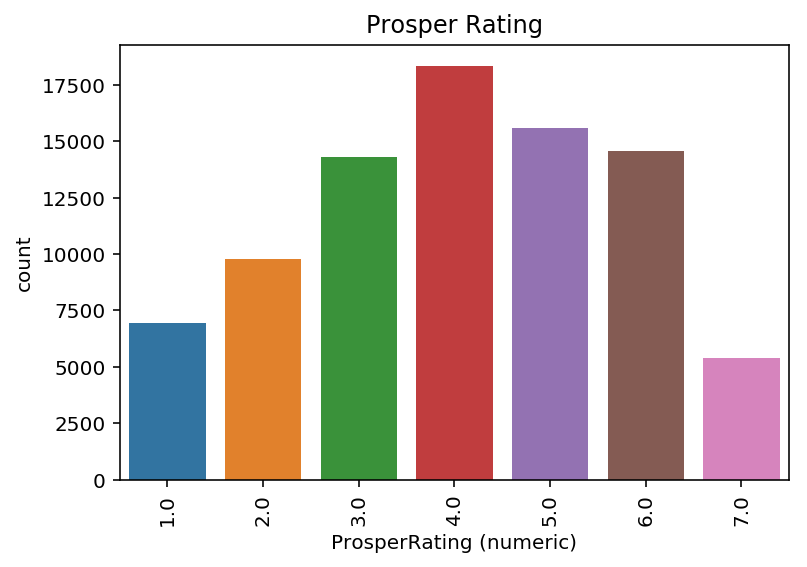

```python
sb.countplot(data=df,x="ProsperRating (numeric)")
plt.xticks(rotation=90);
plt.title("Prosper Rating");
```

The Prosper Rating assigned at the time the listing was created as: 0 - N/A, 1 - HR, 2 - E, 3 - D, 4 - C, 5 - B, 6 - A, 7 - AA. The Rating are Applicable for loans originated after July 2009. The Class C gets the hightest rating of all, followed by B & A.

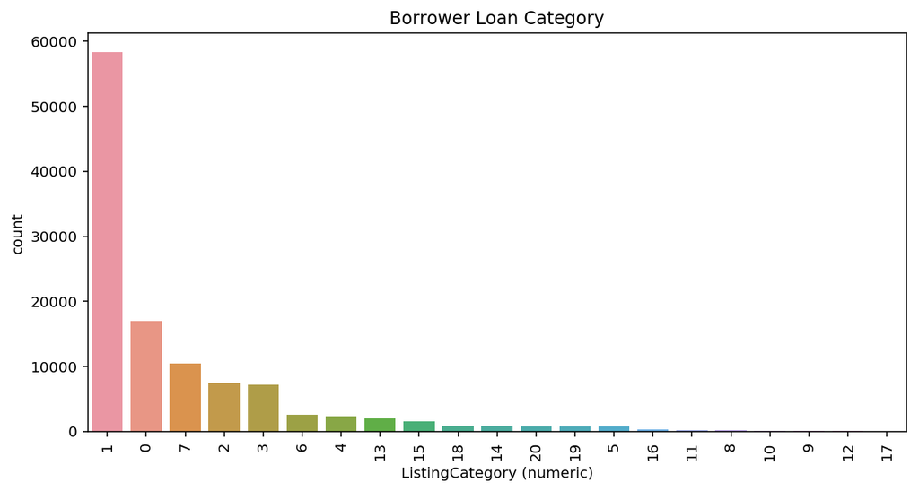

```python
plt.figure(figsize = [10, 5])
order=df['ListingCategory (numeric)'].value_counts()
sb.countplot(data=df,x="ListingCategory (numeric)",order=order.index)
plt.xticks(rotation=90);
plt.title("Borrower Loan Category");
```

The listing category defined are: 0 - Not Available, 1 - Debt Consolidation, 2 - Home Improvement, 3 - Business, 4 - Personal Loan, 5 - Student Use, 6 - Auto, 7- Other, 8 - Baby&Adoption, 9 - Boat, 10 - Cosmetic Procedure, 11 - Engagement Ring, 12 - Green Loans, 13 - Household Expenses, 14 - Large Purchases, 15 - Medical/Dental, 16 - Motorcycle, 17 - RV, 18 - Taxes, 19 - Vacation, 20 - Wedding Loans.

The Bar chart denotes that the most Borrower apply loans for Debt Consolidation, which usually is to pay of other debts.

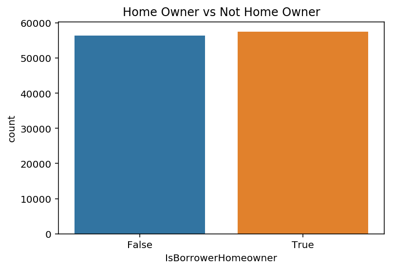

```python
sb.countplot(data=df,x="IsBorrowerHomeowner")
plt.title("Home Owner vs Not Home Owner");
```

A Borrower will be classified as a homowner if they have a mortgage on their credit profile or provide documentation confirming they are a homeowner.

Based on the plot there are almost equal number of Home Owner borrower and non Home Owner Borrower.

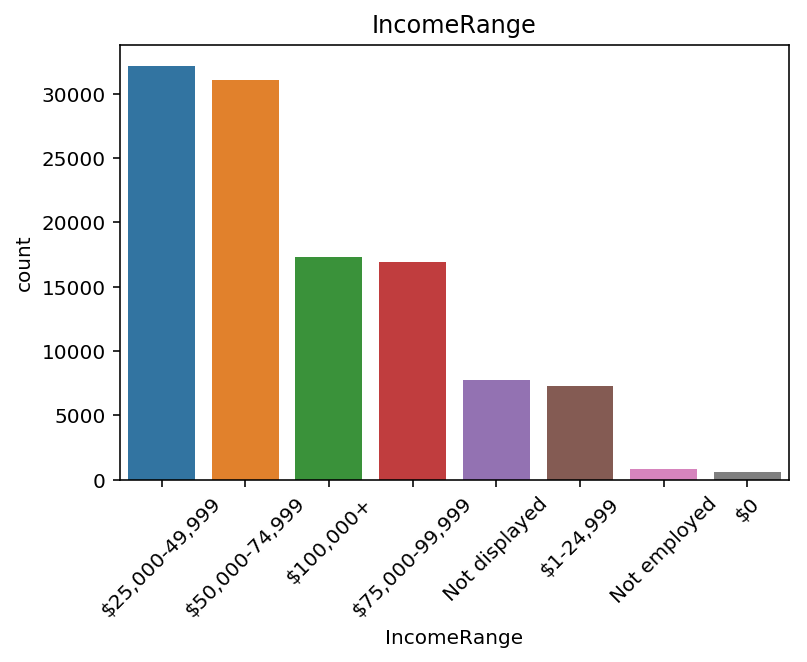

```python
order=df['IncomeRange'].value_counts()
sb.countplot(data=df,x="IncomeRange",order=order.index)

plt.title('IncomeRange')
plt.xticks(rotation=45);
```

Above plot depicts that most borrowers are under the income class of 25k-75k

#### Bivariate Analysis

Analyse IsBorrowerHomeowner and Ratings

```
(0.2611531299204041, 7.738846870079596)
```

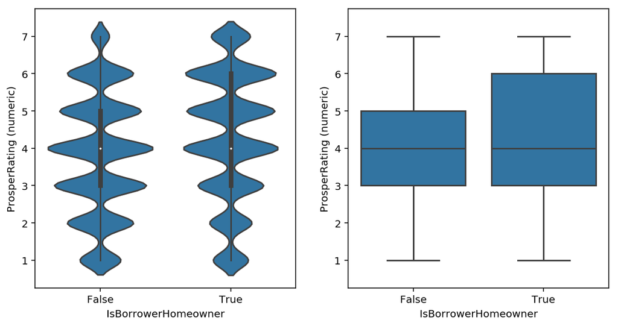

```python
plt.figure(figsize = [10, 5])
base_color = sb.color_palette()[0]

# left plot: violin plot
plt.subplot(1, 2, 1);
ax1 = sb.violinplot(data = df, x = 'IsBorrowerHomeowner', y = 'ProsperRating (numeric)', color = base_color);

# right plot: box plot
plt.subplot(1, 2, 2);
sb.boxplot(data = df, x = 'IsBorrowerHomeowner', y = 'ProsperRating (numeric)', color = base_color);
plt.ylim(ax1.get_ylim()) # set y-axis limits to be same as left plot
```

The Rating distribution between homeowner and non homeowner is not the same considering that the median to be the same.

```
Text(0.5,1,'LoanOriginalAmount vs. BorrowerRate')
```

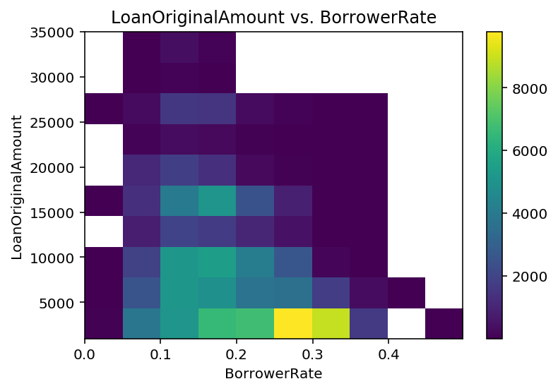

```python
# plots the hist2d graph
plt.hist2d(data=df, x='BorrowerRate', y='LoanOriginalAmount', cmap = 'viridis', cmin = 0.5);
plt.colorbar()

plt.xlabel('BorrowerRate')
plt.ylabel('LoanOriginalAmount')
plt.title('LoanOriginalAmount vs. BorrowerRate')
```

Observations: It is noticed that the rate of the loan is high when the Loan amount borrowed is lower.

```
Text(0,0.5,'Principal Borrowed')
```

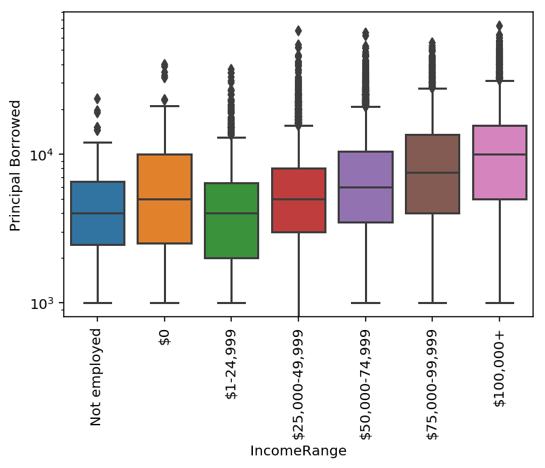

```python
order = ['Not employed', '$0', '$1-24,999', '$25,000-49,999', '$50,000-74,999', '$75,000-99,999', '$100,000+']
sb.boxplot(data=df, x='IncomeRange', y='ProsperPrincipalBorrowed', order=order);
plt.yscale('log')
plt.xticks(rotation=90);
plt.ylabel('Principal Borrowed')
```

The above boxplot depicts that as the Income range increases, the more is the principal amount

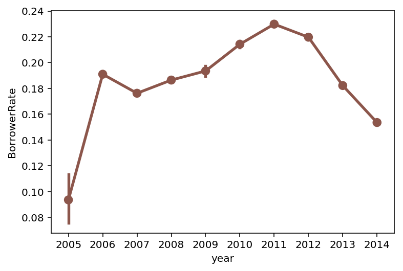

```python
df['year'] = df.ListingCreationDate.str.split('-').str[0]
sb.pointplot(data=df, x='year', y='BorrowerRate',color =sb.color_palette()[5]);
```

The above graph shows that rate of interest rate increased from 2005 to 2006 and then dropped off from 2006-2007 and then it constantly increated for few years, reached its peak in 2011 which then started decreasing until 2014.

##### Multivariate Aanlysis:

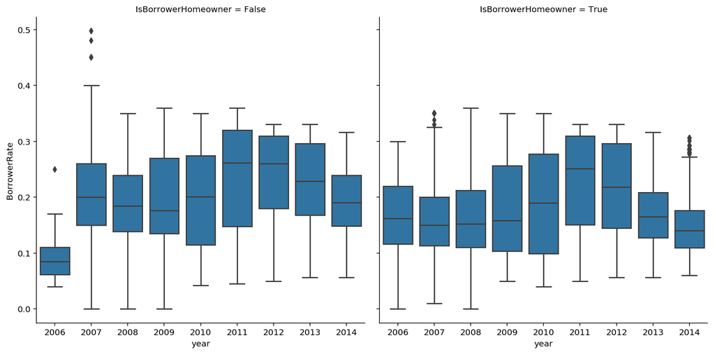

```python
plt.figure(figsize = [10, 5])

g = sb.FacetGrid(data = df, col = 'IsBorrowerHomeowner', size = 6,margin_titles = True)
g.map(sb.boxplot, 'year', 'BorrowerRate')
```